# Assignment 10: Predictive Modeling - Part 1

*How to do it?*:

- Open the Rmarkdown file of this assignment (link) in Rstudio.
- Right under each **question**, insert a code chunk (you can use the hotkey `Ctrl + Alt + I` to add a code chunk) and code the solution for the question.
- `Knit` the rmarkdown file (hotkey: `Ctrl + Alt + K`) to export an html.
- Publish the html file to your Githiub Page.

*Submission*: Submit the link on Github of the assignment to Canvas

1. Install the package `mlbench` and use the follows to import the data

```r
library(mlbench)
data(PimaIndiansDiabetes)
df <- PimaIndiansDiabetes
```

- Set seed to be 2020.
- The target variable is `diabetes`
- Partition the data into 80% training and 20% testing.

```r
# The target variable is the variable at column 9.
names(df)[9] <- 'target'
library(caret)
set.seed(2020)
splitIndex <- createDataPartition(df$target, p = .80,
                                  list = FALSE)
df_train <- df[ splitIndex,]
df_test <- df[-splitIndex,]
```

2. Practice Decision Tree. Do the follows:
- Use `rpart` package, create a decision tree with maximum depth of 3.

```r
df$target <- factor(df$target)
library(rpart)
tree_model <- rpart(target ~ ., data = df_train,
                 control = rpart.control(maxdepth = 3))
```

- Calculate the accuracy of the model on the testing data.

```r
#predict on testing data
pred <- predict(tree_model, df_test, type = "class")
#Evaluate the predictions
cm <- confusionMatrix(data = pred, reference = df_test$target, positive = "pos")
tree3pred <-cm$overall[1]
#72.5% accurate
```

- Plot the tree

```r
library(rattle)
```

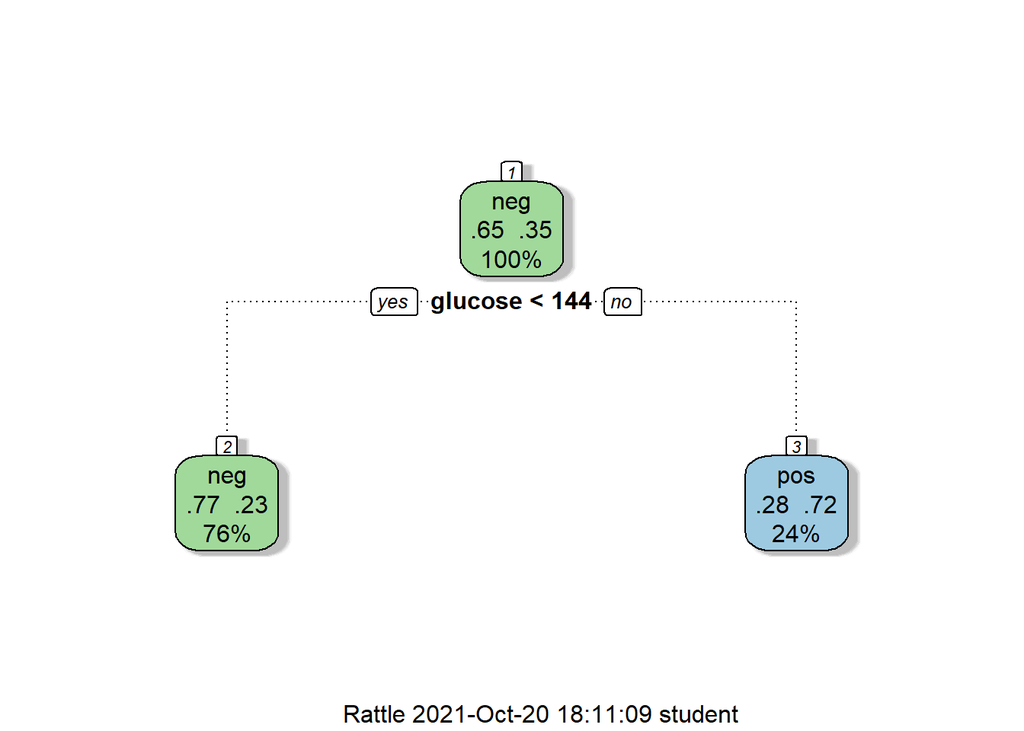

```r
fancyRpartPlot(tree_model)
```

- Plot the variable importance by the tree

```r
tree_model$variable.importance
```

```
##   glucose   insulin  pressure  pedigree
## 53.233124  6.241125  1.101375  0.734250
```

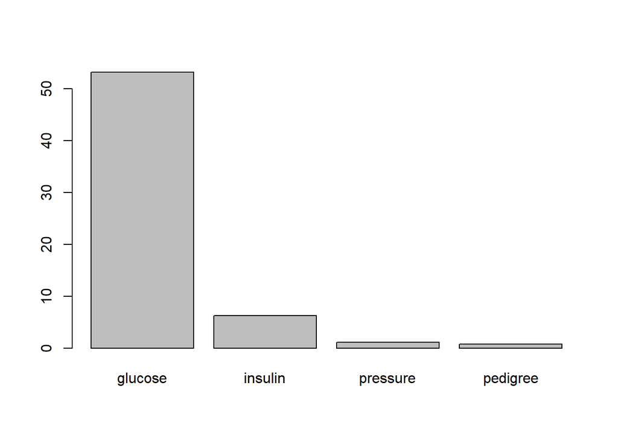

```r
barplot(tree_model$variable.importance)
```

3. Practice Random Forest. Do the follows:
- Use `randomForest` package, create a random forest of 1000 trees.

```r
library(randomForest)
names(df)[9] <- 'target'
library(caret)
set.seed(2020)
splitIndex <- createDataPartition(df$target, p = .80,
                                  list = FALSE)
df_train <- df[ splitIndex,]
df_test <- df[-splitIndex,]
forest_model = randomForest(target ~ ., data=df_train, ntree = 1000)
```

- Calculate the accuracy of the model on the testing data.

```r
pred <- predict(forest_model, df_test, type = "class")
cm <- confusionMatrix(data = pred, reference = df_test$target, positive = "pos")
cm$overall[1]
```

```
##  Accuracy
## 0.7843137
```

- Plot the variable importance by the forest

```r
importance(forest_model)
```

```
##          MeanDecreaseGini
## pregnant         22.05840
## glucose          73.48845
## pressure         25.01980
## triceps          19.23904
## insulin          20.86045
## mass             44.63439
## pedigree         34.56585
## age              37.70683
```

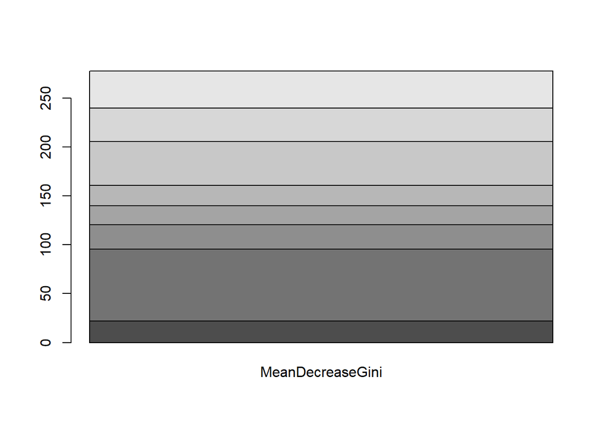

```r
barplot(importance(forest_model))
```

4. Compare the testing accuracy of a forest of 1000 trees and a forest of 2000 trees.

```r
library(randomForest)
names(df)[9] <- 'target'
library(caret)
set.seed(2020)
splitIndex <- createDataPartition(df$target, p = .80,
                                  list = FALSE)
df_train <- df[ splitIndex,]
df_test <- df[-splitIndex,]
forest_model = randomForest(target ~ ., data=df_train, ntree = 1000)
pred <- predict(forest_model, df_test, type = "class")
cm <- confusionMatrix(data = pred, reference = df_test$target, positive = "pos")
forest1kpred <-cm$overall[1]

library(randomForest)
names(df)[9] <- 'target'
library(caret)
set.seed(2020)
splitIndex <- createDataPartition(df$target, p = .80,
                                  list = FALSE)
df_train <- df[ splitIndex,]
df_test <- df[-splitIndex,]
forest_model = randomForest(target ~ ., data=df_train, ntree = 2000)
pred <- predict(forest_model, df_test, type = "class")
cm <- confusionMatrix(data = pred, reference = df_test$target, positive = "pos")
forest2kpred <-cm$overall[1]

forest1kpred
```

```
##  Accuracy
## 0.7843137
```

```r
forest2kpred
```

```
##  Accuracy
## 0.7843137
```

5. Using Caret, create a tree with maximum depth of 3 and forest of 1000 trees. Compare the accuracy of these two models.

```r
set.seed(2020)
model1 <- train(target~., data=df_train,
                method = "rpart2",
                maxdepth=3)
pred <- predict(model1, df_test)
cm <- confusionMatrix(data = pred, reference = df_test$target, positive = "pos")
mod1pred <-cm$overall[1]

set.seed(2020)
model2 <- train(target~., data=df_train,
                method = "rf",
                ntree = 1000)
pred <- predict(model2, df_test)
cm <- confusionMatrix(data = pred, reference = df_test$target, positive = "pos")
mod2pred<-cm$overall[1]

mod1pred
```

```
##  Accuracy
## 0.7254902
```

```r
mod2pred
```

```
##  Accuracy
## 0.7843137
```

```r
#Model 2 (the random forest) predicts better than the single decision tree
```

6. Plot variable importance by the two models in 5.

```r
# Tree
varImp(model1)
```

```
## rpart2 variable importance
##
##          Overall
## glucose   100.00
## age        49.73
## mass       49.25
## pregnant   24.66
## insulin    18.30
## pedigree    0.00
## triceps     0.00
## pressure    0.00
```

```r
#Forest
varImp(model2)
```

```
## rf variable importance
##
##          Overall
## glucose  100.000
## mass      47.108
## age       32.853
## pedigree  28.282
## pressure  10.333
## pregnant   6.431
## insulin    3.480
## triceps    0.000
```

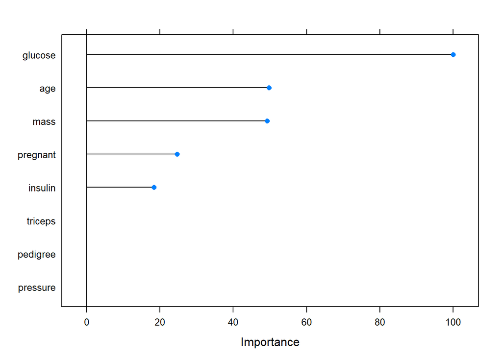

```r
#Plots below
plot(varImp(model1))
```

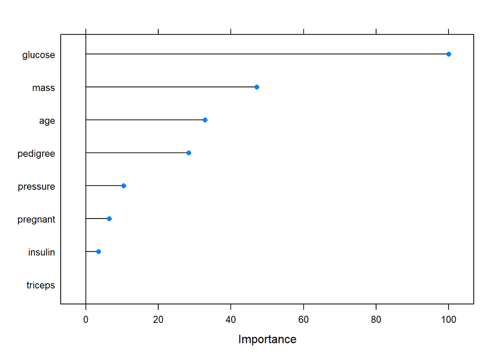

```r
plot(varImp(model2))
```

7. (Optional - For extra credits only) Use your own selected data. Do the follows.

```r
library(tidyverse)
```

```r
library(ggplot2)
df7 <-read_csv("C:/Users/student/Desktop/Data Mining 460/ncaaVB.csv")
df7 <- select(df7,-School)
```

- Handle missing values if any

```r
sum(is.na(df7))
```

```
## [1] 0
```

```r
#There are no missing values in this dataset
```

- Put the variables in the right format (categorical vs. continuous)
- Select a binary target variable (Use can create a binary target variable from a continuous variable).

```r
library(randomForest)
names(df7)[25] <- 'target'
df7$target <- factor(df7$target)
df7$Conference <- factor(df7$Conference)
df7$Region <- factor(df7$Region)
df7$CoachLength <- factor(df7$CoachLength)
```

- Using caret with method `ranger` to train then test the accuracy of a random forest of 1000 trees.

```r
library(caret)
set.seed(2020)
splitIndex <- createDataPartition(df7$target, p = .75,
                                  list = FALSE)
df_train <- df7[ splitIndex,]
df_test <- df7[-splitIndex,]

model2 <- train(target~., data=df_train,
                method = "rf",
                ntree = 1000)
pred <- predict(model2, df_test)

cm <- confusionMatrix(data = pred, reference = df_test$target, positive = "1")
cm$overall[1]
```

```
##  Accuracy
## 0.8765432
```

```r
varImp(model2)
```

```
## rf variable importance
##
##   only 20 most important variables shown (out of 63)
##
##                    Overall
## CoachWL             100.00
## HitPercent           93.01
## WinPercent           85.33
## ReceptionErros       73.91
## Kills                72.30
## Assists              67.95
## OppKills             64.21
## Blocks               61.53
## BallHandlingErrors   60.46
## OppHitPercent        59.82
## AttackErrors         54.00
## OppAttackErrors      46.15
## BlockErrors          45.55
## Aces                 43.66
## CoachTenure          43.39
## Digs                 42.96
## ServeErrors          42.00
## OppAttacks           41.65
## Attacks              41.08
## SetsPerMatch         39.98
```

```r
#Hitting percentage,CoachWL, and WinPercent are the most useful at predicting if a team was in the playoffs in the previous year (the data doesn't have a value for if the team made the playoffs in the current year, so not the best thing to try to predict, but it works for demonstration purposes).
```